# Applied Data Science

# esquisse: Simplifying ggplot2

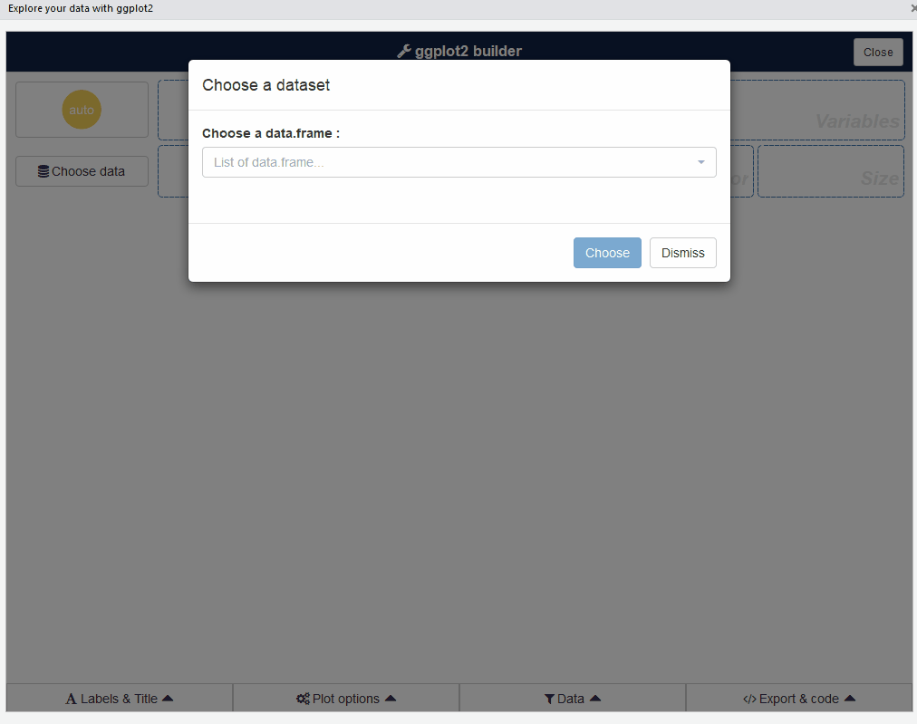

`library(esquisse)`

`esquisser()`

> The purpose of this add-in is to let you explore your data quickly to extract the information they hold.

# R Journalism - a very nice website

https://learn.r-journalism.com/en/

# The Leaflet Package

- Leaflet is the leading open-source JavaScript library for mobile-friendly interactive maps.
- Leaflet is designed with simplicity, performance and usability in mind.
- It works efficiently across all major desktop and mobile platforms, can be extended with lots of plugins
- It has a beautiful, easy to use and well-documented API and a simple, readable source code that is a joy to contribute to.

[figure not shown]